# Relational robotic insertion sort

This notebook implements the **two-loop program from our discussion** in the same Fetch/MuJoCo environment as robotic_insertion_sort.ipynb. It selects objects through `next*`, `keyless`, equality, and quantified guards. Each inner iteration contains **three explicit pick/move/release sequences**; there is no `SwapAdjacent` function or call.

The workflow is: inspect the exact program → watch an actual robot simulation → collect measured loop states → infer clauses with RoboVerify → compare them with the handwritten outer/inner invariants → check a four-object transition model. An inference result is not treated as a proof merely because it fits the traces.

```python
from pathlib import Path
import os
import sys
import inspect
import json
from dataclasses import asdict
from html import escape

os.environ.pop("LD_PRELOAD", None)
ROOT = next(path for path in (Path.cwd(), *Path.cwd().parents)
            if (path / "synthesis" / "inference_lib" / "relational.py").exists())
if str(ROOT) not in sys.path:
    sys.path.insert(0, str(ROOT))
OUT = ROOT / "notebooks"
PREFIX = "relational_robotic_insertion_sort"
RECOLLECT_CORPUS = False  # True reruns every case; False reuses only source-matching physical traces.

import numpy as np
import z3
import imageio.v2 as imageio
import matplotlib.pyplot as plt
from matplotlib.patches import Rectangle
from IPython.display import Code, HTML, Image, Markdown, Video, display

from synthesis.environment.cee_us_env.runtime import configure_local_mujoco
print("MuJoCo runtime:", configure_local_mujoco())
print("Python:", sys.executable)
print("Z3:", z3.get_version_string())

def table(headers, rows):
    display(HTML("<table><thead><tr>" + "".join(f"<th>{escape(str(h))}</th>" for h in headers)
        + "</tr></thead><tbody>" + "".join("<tr>" + "".join(f"<td>{escape(str(v))}</td>" for v in row)
        + "</tr>" for row in rows) + "</tbody></table>"))
```

```
MuJoCo runtime: /Users/luoninz1/Documents/RoboVerify/roboverify/.runtime/mujoco211
Python: /Users/luoninz1/Documents/RoboVerify/roboverify/.venv/bin/python3
Z3: 4.15.4
```

## 1. Exact program and assignment restrictions

`b` is initialized before the outer loop and updated only at its body's end. `r` is initialized before the inner loop and updated only at its body's end. `x` and `p` are existential **witnesses**, bound when a guard succeeds; they are object identities, not indices. The Python walrus notation implements that binding.

There are no `if`/`else` statements, index accesses, pointer dereferences, arbitrary temporary assignments, or return value in the sorting function below. Guard evaluators and controller code are infrastructure: their ordinary Python loops and arrays implement quantification, perception, and actuator coordinates.

The outer guard is $$\exists x.\;(b\ne x)\land b\langle next^*\rangle x\land \bigl(\forall y.\;((b\ne y)\land b\langle next^*\rangle y) \Rightarrow x\langle next^*\rangle y\bigr).$$ The inner guard is $$\exists p.\;(p\ne x)\land p\langle next^*\rangle x\land \bigl(\forall z.\;(p\langle next^*\rangle z\land z\langle next^*\rangle x) \Rightarrow(z=p\lor z=x)\bigr)\land keyless(x,p).$$

```python
from synthesis.examples.relational_robotic_sort import (
    insertion_sort_relational, RelationalScene, RelationalSortSnapshot,
    create_environment, setup_scene, capture_simulator_state,
    TableRobot, SortVideo, block_position,
)
display(Code(inspect.getsource(insertion_sort_relational), language="python"))
```

```
def insertion_sort_relational(head, scene, robot):
    """The exact restricted two-loop program; sorts the measured row in place.

    The walrus assignments bind existential guard witnesses. The only ordinary
    assignments initialize/update b and r at their allowed loop boundaries.
    Targets refer to the measured row frozen by the current inner guard.
    """
    b = head
    while (x := scene.outer_guard(b)) is not None:
        r = x
        while (p := scene.inner_guard(b, x, r)) is not None:
            robot.pick(x)
            robot.move(scene.buffer_position)
            robot.release(scene.buffer_position)
            robot.pick(p)
            robot.move(scene.row_target(x))
            robot.release(scene.row_target(x))
            robot.pick(x)
            robot.move(scene.row_target(p))
            robot.release(scene.row_target(p))
            r = b
        b = r
```

## 2. Measured relations and physical actions

At every guard, all four blocks must occupy distinct row slots and the gripper and temporary buffer must be empty. `next*` is **reflexive** reachability along this measured row; `keyless(u,v)` is the strict comparison of immutable keys. The pose-to-row adapter rejects missing, ambiguous, or duplicate occupancy. It does not infer physical order from an algorithm-maintained sorting array.

During one inner body, targets remain frozen from the preceding observation:

1. Pick `x`, move it to the buffer, release it.
2. Pick `p`, move it to the former row slot of `x`, release it.
3. Pick `x`, move it to the former row slot of `p`, release it.

`scene.row_target(x)` is the row target in that frozen observation, so it remains meaningful while `x` is in the buffer. This is actuator/perception storage, not another sorting cursor. The next guard refreshes all measured positions. All movement after scene initialization advances MuJoCo with `env.step`; the program does not teleport blocks. A loop invariant need not hold between these three transfers, when the row temporarily contains a vacancy.

```python
display(Code(inspect.getsource(RelationalScene.outer_guard), language="python"))
display(Code(inspect.getsource(RelationalScene.inner_guard), language="python"))
env, slots, buffer_position = create_environment(num_blocks=4, seed=23)
baseline = capture_simulator_state(env)
print("Objects:", tuple(env.object_names))
print("Row spacing: 0.11 m; one temporary table buffer")
```

```
    def outer_guard(self, b: str) -> str | None:
        """∃x. b≠x ∧ b next* x ∧ ∀y. (b≠y ∧ b next* y) ⇒ x next* y."""
        self.refresh()
        witnesses = [x for x in self.objects
                     if b != x and self.next_star(b, x)
                     and all(not (b != y and self.next_star(b, y))
                             or self.next_star(x, y) for y in self.objects)]
        if len(witnesses) > 1:
            raise AssertionError("Outer guard is not functional on the measured list.")
        self._record("outer_head" if witnesses else "outer_exit", b)
        return witnesses[0] if witnesses else None
```

```
    def inner_guard(self, b: str, x: str, r: str) -> str | None:
        """∃p. p≠x ∧ p next* x ∧ ∀z. (p next* z ∧ z next* x)
        ⇒ (z=p ∨ z=x), conjoined with keyless(x,p).
        """
        self.refresh()
        witnesses = [p for p in self.objects
                     if p != x and self.next_star(p, x)
                     and all(not (self.next_star(p, z) and self.next_star(z, x))
                             or z == p or z == x for z in self.objects)
                     and self.keyless(x, p)]
        if len(witnesses) > 1:
            raise AssertionError("Inner guard is not functional on the measured list.")
        self._record("inner_head" if witnesses else "inner_exit", b, x, r)
        if witnesses:
            self.robot.description = f"Insert key {self.keys[x]}: pass key {self.keys[witnesses[0]]}"
        return witnesses[0] if witnesses else None
```

```
Objects: ('object0', 'object1', 'object2', 'object3')
Row spacing: 0.11 m; one temporary table buffer
```

## 3. Execute and record a reverse-order demonstration

This cell always performs a fresh simulation, including when the corpus below is reused. Colors identify physical blocks; keys stay attached to those identities. The three transfers in each exchange are visible in the video.

```python
initial_order = tuple(str(name) for name in env.object_names)
keys = dict(zip(initial_order, (4, 3, 2, 1)))
setup_scene(env, slots, buffer_position, initial_order, keys, baseline=baseline)
robot = TableRobot(env, slots, keys)
VIDEO = OUT / f"{PREFIX}.mp4"
recorder = SortVideo(env, keys, slots, buffer_position, VIDEO, width=960, height=720)
robot.recorder = recorder
scene = RelationalScene(initial_order, keys, slots, buffer_position, robot,
                        lambda name: block_position(env, name),
                        initial_order=initial_order, case_name="reverse_demo")
imageio.imwrite(OUT / f"{PREFIX}_initial.png", recorder.frame(robot))
try:
    recorder.pause(robot, 1)
    insertion_sort_relational(initial_order[0], scene, robot)
    final = scene.snapshots[-1]
    assert final.order == tuple(sorted(initial_order, key=keys.__getitem__))
    assert robot.held is None and not final.buffered
    robot.description, robot.phase = "Measured sorted row verified", "Complete"
    recorder.pause(robot, 1)
    imageio.imwrite(OUT / f"{PREFIX}_final.png", recorder.frame(robot))
finally:
    recorder.close()
    robot.recorder = None
demo = {"source": "fresh actual Fetch simulation", "initial_order": initial_order,
        "keys": keys, "final_order": final.order, "steps": robot.steps,
        "transfers": robot.transfers, "snapshots": [asdict(s) for s in scene.snapshots]}
(OUT / f"{PREFIX}_demo.json").write_text(json.dumps(demo, indent=2) + "\n")
table(["Initial keys", "Final keys", "Exchanges", "Transfers", "Physics steps"],
      [[list(keys.values()), [keys[u] for u in final.order],
        sum(s.program_point == "inner_head" for s in scene.snapshots),
        len(robot.transfers), robot.steps]])
display(Video(filename=str(VIDEO), embed=True, width=850))
```

```
Creating offscreen glfw
```

| Initial keys | Final keys | Exchanges | Transfers | Physics steps |
| --- | --- | --- | --- | --- |
| [4, 3, 2, 1] | [1, 2, 3, 4] | 6 | 18 | 2906 |

[video not shown]

## 4. Inspect the measured loop boundaries

Rows below are observations at guards, including false-guard exits. `outer_head` and `outer_exit` are combined for the outer invariant; `inner_head` and `inner_exit` are combined for the inner invariant. The latter includes zero-swap iterations and the state after `r = b`; omitting exits would bias the data toward states satisfying the guard.

`b`, `x`, and `r` denote object identities. The original `head` object may move; the algorithm does not rely on it remaining at the front.

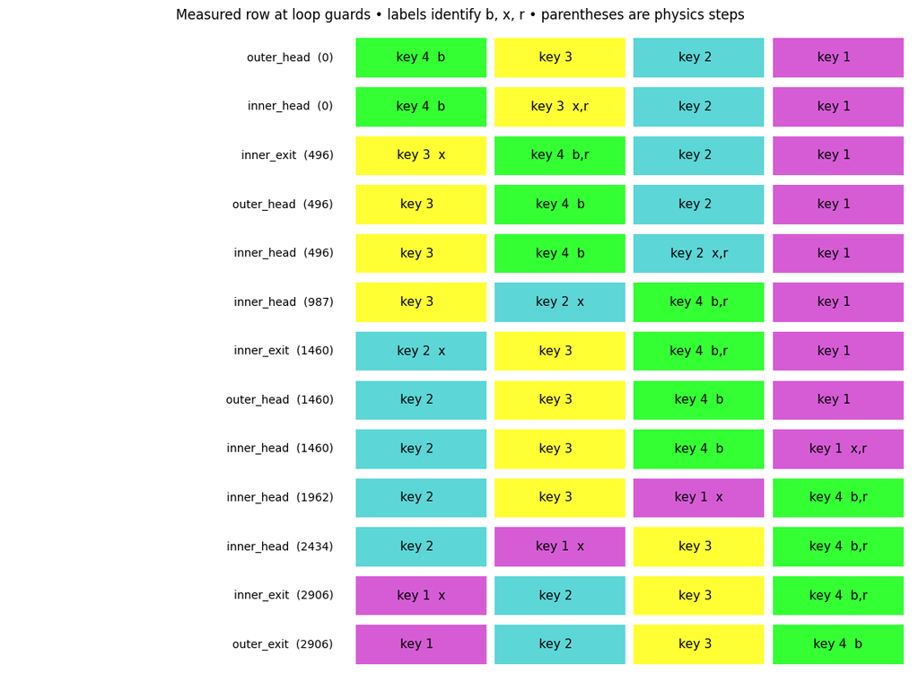

| Point | b | x | r | Measured keys |
| --- | --- | --- | --- | --- |
| outer_head | object0 | None | None | [4, 3, 2, 1] |
| inner_head | object0 | object1 | object1 | [4, 3, 2, 1] |
| inner_exit | object0 | object1 | object0 | [3, 4, 2, 1] |
| outer_head | object0 | None | None | [3, 4, 2, 1] |
| inner_head | object0 | object2 | object2 | [3, 4, 2, 1] |
| inner_head | object0 | object2 | object0 | [3, 2, 4, 1] |
| inner_exit | object0 | object2 | object0 | [2, 3, 4, 1] |
| outer_head | object0 | None | None | [2, 3, 4, 1] |
| inner_head | object0 | object3 | object3 | [2, 3, 4, 1] |
| inner_head | object0 | object3 | object0 | [2, 3, 1, 4] |
| inner_head | object0 | object3 | object0 | [2, 1, 3, 4] |
| inner_exit | object0 | object3 | object0 | [1, 2, 3, 4] |
| outer_exit | object0 | None | None | [1, 2, 3, 4] |

```python
states = scene.snapshots
fig, ax = plt.subplots(figsize=(11.5, 0.55 * len(states) + 1.4))
block_colors = {}
for obj in initial_order:
    geom = env.sim.model.geom_name2id(obj)
    material = env.sim.model.geom_matid[geom]
    rgba = env.sim.model.mat_rgba[material] if material >= 0 else env.sim.model.geom_rgba[geom]
    block_colors[obj] = tuple(rgba[:3])
for row, s in enumerate(states):
    for col, obj in enumerate(s.order):
        ax.add_patch(Rectangle((col, row), 0.94, 0.8,
                              facecolor=block_colors[obj], alpha=.8))
        markers = ",".join(name for name in ("b", "x", "r") if getattr(s, name) == obj)
        ax.text(col + .47, row + .4, f"key {s.key_map[obj]}  {markers}",
                ha="center", va="center", color="black", fontsize=11)
    ax.text(-.16, row + .4, f"{s.program_point}  ({s.step})", ha="right", va="center")
ax.set_xlim(-2.5, 4); ax.set_ylim(len(states), -.25); ax.axis("off")
ax.set_title("Measured row at loop guards • labels identify b, x, r • parentheses are physics steps")
fig.tight_layout()
TRACE_FIGURE = OUT / f"{PREFIX}_trace.png"
fig.savefig(TRACE_FIGURE, dpi=160, bbox_inches="tight")
plt.show()
table(["Point", "b", "x", "r", "Measured keys"],
      [[s.program_point, s.b, s.x, s.r, [s.key_map[u] for u in s.order]] for s in states])
```

## 5. Predicate vocabulary and separation from the targets

The learner consumes `RelationSpec` evaluators. The unary features below merely fix one argument of a primitive relation to a program variable; **none evaluates whether a prefix is sorted**. They keep the Boolean vocabulary small while retaining the meaning of the original formulas. The `b`, `x`, and `r` bindings are held in the snapshot, not introduced into the sorting program.

| Predicate | Exact meaning |
| --- | --- |
| `NextStar(u,v)` | $u\langle next^*\rangle v$, from measured row order, including self-reachability |
| `KeyLess(u,v)` | $keyless(u,v)$, strict key comparison |
| `BeforeB(u)` | $u\langle next^*\rangle b$ |
| `BeforeR(u)` | $u\langle next^*\rangle r$ |
| `IsB(u)` | $u=b$ |
| `IsX(u)` | $u=x$ |
| `AfterX(u)` | $x\langle next^*\rangle u$ |
| `SelectedLess(u)` | $keyless(x,u)$ |

Inference uses only mathematical order axioms. For later comparison, definitional axioms expand the unary features into the primitive formulas above. The sorting targets are not axioms, not input features, and not training labels.

```python
from synthesis.examples.relational_sort_inference import (
    relation_value, infer_loop, PROJECTIONS, target_formulas,
)
display(Code(inspect.getsource(relation_value), language="python"))
display(Code(inspect.getsource(infer_loop), language="python"))
table(["Loop", "Projection", "Relations", "Universal variables k"],
      [[phase, name, ", ".join(names), k]
       for phase, projections in PROJECTIONS.items() for name, names, k in projections])
```

```
def relation_value(name: str, snapshot: RelationalSnapshot, args: tuple[str, ...]) -> bool:
    state = snapshot.payload
    u = args[0]
    # Ranks belong to the perception adapter, not the sorting program.
    rank = {block: position for position, block in enumerate(state.order)}
    if name == "NextStar":
        return rank[u] <= rank[args[1]]
    if name == "KeyLess":
        return state.key_map[u] < state.key_map[args[1]]
    if name == "BeforeB":
        return rank[u] <= rank[state.b]
    if name == "BeforeR":
        return rank[u] <= rank[state.r]
    if name == "IsB":
        return u == state.b
    if name == "IsX":
        return u == state.x
    if name == "AfterX":
        return rank[state.x] <= rank[u]
    if name == "SelectedLess":
        return state.key_map[state.x] < state.key_map[u]
    raise KeyError(name)
```

```
def infer_loop(states: Sequence[Any], phase: str) -> LearnedLoop:
    selected = phase_states(states, phase)
    if not selected:
        raise ValueError(f"No {phase} snapshots")
    results = {}
    started = perf_counter()
    for name, names, k in PROJECTIONS[phase]:
        domain = build_domain(names)
        snapshots = tuple(adapt_snapshot(state) for state in selected)
        for snapshot in snapshots:
            if not all(evaluate_formula(ax, domain, snapshot) for ax in mathematical_axioms(domain)):
                raise AssertionError(f"Invalid observation in {snapshot.payload.case_name}")
        print(f"Infer {phase}/{name}: {len(snapshots)} physical snapshots, k={k}", flush=True)
        results[name] = infer_relational_invariants(domain, snapshots, k=k, verbose=False)
    full = build_domain(OUTER_NAMES if phase == "outer" else INNER_NAMES, definitions=True)
    return LearnedLoop(phase, full, results, z3.And(*(result.invariant for result in results.values())),
                       perf_counter() - started)
```

| Loop | Projection | Relations | Universal variables k |
| --- | --- | --- | --- |
| outer | prefix_order | BeforeB, NextStar, KeyLess | 2 |
| inner | boundary | BeforeB, BeforeR, IsX | 1 |
| inner | distinct_cursors | IsB, IsX | 1 |
| inner | order_except_selected | BeforeR, IsX, NextStar, KeyLess | 2 |
| inner | passed_blocks | BeforeR, AfterX, IsX, SelectedLess | 1 |

## 6. Physical training and held-out corpus

The corpus contains all 24 permutations of four distinct keys, plus equal, duplicate, and negative-key cases. Entire runs are split before learning; held-out snapshots are never supplied to `infer_relational_invariants`. The reverse-order video is for illustration and is not automatically appended to training. The default reuse path checks the program/controller source hashes. Set `RECOLLECT_CORPUS = True` above to repeat all physical runs.

```python
from synthesis.examples.relational_sort_experiment import (
    collect_corpus, corpus_snapshots, infer_and_validate, source_hashes,
)
TRACES = OUT / f"{PREFIX}_traces.json"
REPORT = OUT / f"{PREFIX}_invariants.json"
if RECOLLECT_CORPUS or not TRACES.exists():
    corpus = collect_corpus(env, slots, buffer_position, baseline, TRACES)
else:
    corpus = json.loads(TRACES.read_text())
    assert corpus["source_sha256"] == source_hashes(), "Program changed: recollect the physical corpus."
    print("Reusing source-verified ACTUAL physical runs from", TRACES.name)
assert all(case["status"] == "passed" for case in corpus["cases"])
table(["Case", "Split", "Initial keys", "Status", "Swaps", "Max pose error (mm)"],
      [[case["name"], case["split"], case["keys"], case["status"],
        case["run"]["swaps"], round(1000 * case["run"]["max_position_error"], 3)]
       for case in corpus["cases"]])
```

```
Reusing source-verified ACTUAL physical runs from relational_robotic_insertion_sort_traces.json
```

| Case | Split | Initial keys | Status | Swaps | Max pose error (mm) |
| --- | --- | --- | --- | --- | --- |
| permutation_00 | train | [1, 2, 3, 4] | passed | 0 | 0.0 |
| permutation_01 | held_out | [1, 2, 4, 3] | passed | 1 | 1.709 |
| permutation_02 | train | [1, 3, 2, 4] | passed | 1 | 2.125 |
| permutation_03 | held_out | [1, 3, 4, 2] | passed | 2 | 2.06 |
| permutation_04 | train | [1, 4, 2, 3] | passed | 2 | 2.128 |
| permutation_05 | held_out | [1, 4, 3, 2] | passed | 3 | 1.991 |
| permutation_06 | train | [2, 1, 3, 4] | passed | 1 | 2.742 |
| permutation_07 | held_out | [2, 1, 4, 3] | passed | 2 | 2.744 |
| permutation_08 | train | [2, 3, 1, 4] | passed | 2 | 2.669 |
| permutation_09 | held_out | [2, 3, 4, 1] | passed | 3 | 2.585 |
| permutation_10 | train | [2, 4, 1, 3] | passed | 3 | 2.667 |
| permutation_11 | held_out | [2, 4, 3, 1] | passed | 4 | 2.508 |
| permutation_12 | train | [3, 1, 2, 4] | passed | 2 | 2.744 |
| permutation_13 | held_out | [3, 1, 4, 2] | passed | 3 | 2.745 |
| permutation_14 | train | [3, 2, 1, 4] | passed | 3 | 2.581 |
| permutation_15 | held_out | [3, 2, 4, 1] | passed | 4 | 2.501 |
| permutation_16 | train | [3, 4, 1, 2] | passed | 4 | 2.671 |
| permutation_17 | held_out | [3, 4, 2, 1] | passed | 5 | 2.409 |
| permutation_18 | train | [4, 1, 2, 3] | passed | 3 | 2.746 |
| permutation_19 | held_out | [4, 1, 3, 2] | passed | 4 | 2.747 |
| permutation_20 | train | [4, 2, 1, 3] | passed | 4 | 2.584 |
| permutation_21 | held_out | [4, 2, 3, 1] | passed | 5 | 2.406 |
| permutation_22 | train | [4, 3, 1, 2] | passed | 5 | 2.582 |
| permutation_23 | held_out | [4, 3, 2, 1] | passed | 6 | 2.371 |
| train_ties_0 | train | [2, 1, 2, 1] | passed | 3 | 2.746 |
| train_ties_1 | train | [2, 2, 2, 2] | passed | 0 | 0.0 |
| train_ties_2 | train | [1, 3, 2, 2] | passed | 2 | 2.128 |
| train_ties_3 | train | [3, 2, 2, 1] | passed | 5 | 2.406 |
| train_ties_4 | train | [0, -1, 2, -1] | passed | 3 | 2.745 |
| train_ties_5 | train | [1, 0, 1, 1] | passed | 1 | 2.742 |
| held_out_ties_0 | held_out | [-2, 4, -2, 1] | passed | 2 | 2.128 |
| held_out_ties_1 | held_out | [2, 1, 1, 2] | passed | 2 | 2.744 |
| held_out_ties_2 | held_out | [3, 3, 1, 2] | passed | 4 | 2.672 |

## 7. The handwritten invariants to compare

These are the formulas derived in our discussion, under a finite nonempty acyclic list with unchanged node identities and keys. They apply at loop heads and exits, not halfway through a physical exchange.

$$I_{outer}\equiv \forall u,v.\; (u\langle next^*\rangle v\land v\langle next^*\rangle b) \Rightarrow\neg keyless(v,u).$$

The inner invariant is the conjunction of these four clauses:

1. $b\ne x$.
2. $\forall u.\;u\langle next^*\rangle r\Leftrightarrow (u\langle next^*\rangle b\lor u=x)$.
3. $\forall u,v.\;(u\ne x\land v\ne x\land u\langle next^*\rangle v \land v\langle next^*\rangle r)\Rightarrow\neg keyless(v,u)$.
4. $\forall u.\;(u\ne x\land x\langle next^*\rangle u \land u\langle next^*\rangle r)\Rightarrow keyless(x,u)$.

Clause 2 identifies the enlarged prefix; clause 3 says it is sorted except possibly for `x`; clause 4 says all blocks that `x` has passed have larger keys. The usual sorted-prefix insertion argument is described in [Princeton §4.2, “Insertion sort”](https://introcs.cs.princeton.edu/java/42sort/); the `b/x/r` relational formulas here are our derivation for this program.

## 8. Infer actual clauses, then compare

Each projection invokes RoboVerify's existing `infer_relational_invariants`. The resulting universally quantified clauses are conjoined without substituting the handwritten target. `target_atom` in the provenance is the Boolean learner's pivot atom; it does not mean a supplied sorting specification.

**Consistency** asks whether learned and handwritten invariants can hold together. **Implication** asks whether the learned clauses establish every handwritten clause. **Equivalence** additionally asks whether the handwritten invariant implies the learned result. A satisfiable conjunction alone proves neither implication nor equivalence. `unknown` is never reported as proof.

```python
learned, report = infer_and_validate(corpus, REPORT)
table(["Loop", "Train snapshots", "Held-out snapshots", "Held-out violations", "Learned clauses"],
      [[phase, item["training"]["snapshots_checked"], item["held_out"]["snapshots_checked"],
        len(item["held_out"]["violations"]), sum(len(p["clauses"]) for p in item["projections"].values())]
       for phase, item in report["loops"].items()])
for phase, loop in learned.items():
    display(Markdown(f"**Actual inferred {phase} formula**"))
    display(Code(loop.invariant.sexpr(), language="lisp"))
    table(["Projection", "Pivot atom", "Learned via", "Retained clause"],
          [[name, clause["target_atom"], clause["learned_via"], clause["expression"]]
           for name, projection in report["loops"][phase]["projections"].items()
           for clause in projection["clauses"]])
```

```
Infer outer/prefix_order: 72 physical snapshots, k=2
```

```
outer comparison: entails=True; equivalent=True
```

```
Infer inner/boundary: 98 physical snapshots, k=1
```

```
Infer inner/distinct_cursors: 98 physical snapshots, k=1
```

```
Infer inner/order_except_selected: 98 physical snapshots, k=2
```

```
Infer inner/passed_blocks: 98 physical snapshots, k=1
```

```
inner comparison: entails=True; equivalent=True
```

| Loop | Train snapshots | Held-out snapshots | Held-out violations | Learned clauses |
| --- | --- | --- | --- | --- |
| outer | 72 | 60 | 0 | 2 |
| inner | 98 | 95 | 0 | 17 |

**Actual inferred outer formula**

```
(let ((a!1 (forall ((ux1 RelationalInsertionBlock)
                    (ux2 RelationalInsertionBlock))
             (or (BeforeB ux1) (not (BeforeB ux2)) (not (NextStar ux1 ux2)))))
      (a!2 (forall ((ux1 RelationalInsertionBlock)
                    (ux2 RelationalInsertionBlock))
             (or (not (KeyLess ux1 ux2))
                 (not (NextStar ux2 ux1))
                 (not (BeforeB ux1))))))
  (and a!1 a!2))
```

| Projection | Pivot atom | Learned via | Retained clause |
| --- | --- | --- | --- |
| prefix_order | BeforeB(ux1) | phi | (forall ((ux1 RelationalInsertionBlock) (ux2 RelationalInsertionBlock)) (or (BeforeB ux1) (not (BeforeB ux2)) (not (NextStar ux1 ux2)))) |
| prefix_order | BeforeB(ux1) | phi_prime | (forall ((ux1 RelationalInsertionBlock) (ux2 RelationalInsertionBlock)) (or (not (KeyLess ux1 ux2)) (not (NextStar ux2 ux1)) (not (BeforeB ux1)))) |

**Actual inferred inner formula**

```
(let ((a!1 (forall ((ux1 RelationalInsertionBlock))
             (or (BeforeB ux1) (BeforeR ux1) (not (IsX ux1)))))
      (a!2 (forall ((ux1 RelationalInsertionBlock))
             (or (BeforeB ux1) (IsX ux1) (not (BeforeR ux1)))))
      (a!3 (forall ((ux1 RelationalInsertionBlock))
             (or (not (BeforeB ux1)) (BeforeR ux1))))
      (a!4 (forall ((ux1 RelationalInsertionBlock))
             (or (not (IsB ux1)) (not (IsX ux1)))))
      (a!5 (forall ((ux1 RelationalInsertionBlock))
             (or (BeforeR ux1) (not (IsX ux1)))))
      (a!6 (forall ((ux1 RelationalInsertionBlock)
                    (ux2 RelationalInsertionBlock))
             (or (BeforeR ux1) (not (BeforeR ux2)) (not (NextStar ux1 ux2)))))
      (a!7 (forall ((ux1 RelationalInsertionBlock)
                    (ux2 RelationalInsertionBlock))
             (or (not (KeyLess ux2 ux1))
                 (IsX ux2)
                 (NextStar ux2 ux1)
                 (IsX ux1)
                 (not (BeforeR ux1))
                 (KeyLess ux1 ux2)
                 (not (BeforeR ux2)))))
      (a!8 (forall ((ux1 RelationalInsertionBlock)
                    (ux2 RelationalInsertionBlock))
             (or (IsX ux2)
                 (NextStar ux2 ux1)
                 (not (BeforeR ux1))
                 (KeyLess ux1 ux2)
                 (not (BeforeR ux2))
                 (KeyLess ux2 ux1)
                 (not (IsX ux1)))))
      (a!9 (forall ((ux1 RelationalInsertionBlock)
                    (ux2 RelationalInsertionBlock))
             (or (not (KeyLess ux2 ux1))
                 (IsX ux2)
                 (NextStar ux2 ux1)
                 (not (BeforeR ux1))
                 (KeyLess ux1 ux2)
                 (not (BeforeR ux2))
                 (not (IsX ux1)))))
```

[output cut: 38 more lines]

```
       a!3
       a!4
       a!5
       a!6
       a!7
       a!8
       a!9
       a!10
       a!11
       a!12
       (forall ((ux1 RelationalInsertionBlock)) (or (BeforeR ux1) (AfterX ux1)))
       a!5
       a!13
       a!14
       a!15))
```

| Projection | Pivot atom | Learned via | Retained clause |
| --- | --- | --- | --- |
| boundary | BeforeB(ux1) | phi | (forall ((ux1 RelationalInsertionBlock)) (or (BeforeB ux1) (BeforeR ux1) (not (IsX ux1)))) |
| boundary | BeforeB(ux1) | phi | (forall ((ux1 RelationalInsertionBlock)) (or (BeforeB ux1) (IsX ux1) (not (BeforeR ux1)))) |
| boundary | BeforeB(ux1) | phi_prime | (forall ((ux1 RelationalInsertionBlock)) (or (not (BeforeB ux1)) (BeforeR ux1))) |
| distinct_cursors | IsB(ux1) | phi_prime | (forall ((ux1 RelationalInsertionBlock)) (or (not (IsB ux1)) (not (IsX ux1)))) |
| order_except_selected | BeforeR(ux1) | phi | (forall ((ux1 RelationalInsertionBlock)) (or (BeforeR ux1) (not (IsX ux1)))) |
| order_except_selected | BeforeR(ux1) | phi | (forall ((ux1 RelationalInsertionBlock) (ux2 RelationalInsertionBlock)) (or (BeforeR ux1) (not (BeforeR ux2)) (not (NextStar ux1 ux2)))) |
| order_except_selected | BeforeR(ux1) | phi_prime | (forall ((ux1 RelationalInsertionBlock) (ux2 RelationalInsertionBlock)) (or (not (KeyLess ux2 ux1)) (IsX ux2) (NextStar ux2 ux1) (IsX ux1) (not (BeforeR ux1)) (KeyLess ux1 ux2) (not (BeforeR ux2)))) |
| order_except_selected | BeforeR(ux1) | phi_prime | (forall ((ux1 RelationalInsertionBlock) (ux2 RelationalInsertionBlock)) (or (IsX ux2) (NextStar ux2 ux1) (not (BeforeR ux1)) (KeyLess ux1 ux2) (not (BeforeR ux2)) (KeyLess ux2 ux1) (not (IsX ux1)))) |
| order_except_selected | BeforeR(ux1) | phi_prime | (forall ((ux1 RelationalInsertionBlock) (ux2 RelationalInsertionBlock)) (or (not (KeyLess ux2 ux1)) (IsX ux2) (NextStar ux2 ux1) (not (BeforeR ux1)) (KeyLess ux1 ux2) (not (BeforeR ux2)) (not (IsX ux1… |
| order_except_selected | BeforeR(ux1) | phi_prime | (forall ((ux1 RelationalInsertionBlock) (ux2 RelationalInsertionBlock)) (or (NextStar ux2 ux1) (not (BeforeR ux1)) (KeyLess ux1 ux2) (not (BeforeR ux2)) (KeyLess ux2 ux1) (not (IsX ux1)) (not (IsX ux2… |
| order_except_selected | BeforeR(ux1) | phi_prime | (forall ((ux1 RelationalInsertionBlock) (ux2 RelationalInsertionBlock)) (or (not (KeyLess ux2 ux1)) (NextStar ux2 ux1) (not (BeforeR ux1)) (KeyLess ux1 ux2) (not (BeforeR ux2)) (not (IsX ux1)) (not (I… |
| order_except_selected | BeforeR(ux1) | phi_prime | (forall ((ux1 RelationalInsertionBlock) (ux2 RelationalInsertionBlock)) (or (not (KeyLess ux1 ux2)) (NextStar ux2 ux1) (not (BeforeR ux1)) (not (BeforeR ux2)) (KeyLess ux2 ux1) (not (IsX ux1)) (not (I… |
| passed_blocks | BeforeR(ux1) | phi | (forall ((ux1 RelationalInsertionBlock)) (or (BeforeR ux1) (AfterX ux1))) |
| passed_blocks | BeforeR(ux1) | phi | (forall ((ux1 RelationalInsertionBlock)) (or (BeforeR ux1) (not (IsX ux1)))) |
| passed_blocks | BeforeR(ux1) | phi_prime | (forall ((ux1 RelationalInsertionBlock)) (or (not (BeforeR ux1)) (not (IsX ux1)) (AfterX ux1))) |
| passed_blocks | BeforeR(ux1) | phi_prime | (forall ((ux1 RelationalInsertionBlock)) (or (not (BeforeR ux1)) (not (IsX ux1)) (not (SelectedLess ux1)))) |
| passed_blocks | BeforeR(ux1) | phi_prime | (forall ((ux1 RelationalInsertionBlock)) (or (IsX ux1) (not (BeforeR ux1)) (SelectedLess ux1) (not (AfterX ux1)))) |

```python
rows=[]
for phase, item in report["loops"].items():
    comparison=item["comparison"]
    rows.append([phase, "axioms + learned + handwritten", comparison["joint_satisfiable"]["status"],
                 "sat means compatible"])
    for name, result in comparison["learned_implies_each_target"].items():
        rows.append([phase, f"learned AND NOT {name}", result["status"], "unsat proves the target clause"])
    rows.append([phase, "handwritten AND NOT learned", comparison["theory_implies_learned"]["status"],
                 "unsat proves reverse implication"])
table(["Loop", "Solver query (plus axioms)", "Result", "Interpretation"], rows)
for phase, item in report["loops"].items():
    comparison=item["comparison"]
    display(Markdown(f"**{phase.capitalize()}:** consistent = `{comparison['consistent']}`; "
                     f"entails all handwritten clauses = `{comparison['entails_theory']}`; "
                     f"equivalent under the stated axioms = `{comparison['equivalent']}`."))
    assert comparison["candidate_satisfiable"]["status"] == "sat", "Avoid vacuous implication."
    assert all(result["status"] == "sat" for result in comparison["targets_not_assumed"].values()), \
        "A handwritten target must not already follow from the supplied axioms."
```

| Loop | Solver query (plus axioms) | Result | Interpretation |
| --- | --- | --- | --- |
| outer | axioms + learned + handwritten | sat | sat means compatible |
| outer | learned AND NOT sorted_prefix | unsat | unsat proves the target clause |
| outer | handwritten AND NOT learned | unsat | unsat proves reverse implication |
| inner | axioms + learned + handwritten | sat | sat means compatible |
| inner | learned AND NOT distinct_b_x | unsat | unsat proves the target clause |
| inner | learned AND NOT prefix_boundary | unsat | unsat proves the target clause |
| inner | learned AND NOT sorted_except_x | unsat | unsat proves the target clause |
| inner | learned AND NOT passed_blocks_strictly_larger | unsat | unsat proves the target clause |
| inner | handwritten AND NOT learned | unsat | unsat proves reverse implication |

**Outer:** consistent = `True`; entails all handwritten clauses = `True`; equivalent under the stated axioms = `True`.

**Inner:** consistent = `True`; entails all handwritten clauses = `True`; equivalent under the stated axioms = `True`.

## 9. Symbolic transition checks and their scope

The verifier interprets the **actual learned clauses** over four node identities, all row permutations, and arbitrary integer keys (including ties). It checks initialization, outer-to-inner entry, inner preservation, inner exit, outer exit, and decreasing progress measures. It separately composes the three transfers, checking empty destinations and recovery of the swapped row.

Each obligation requires a **SAT premise** and an **UNSAT counterexample query**. The symbolic transfer contract assumes successful grasp/release and unchanged positions of other blocks. The checks do not verify continuous controller behavior or automatically prove that Python implements the model. The relation comparison is distinct from this fixed-four-object transition check.

```python
verification=report["abstract_verification"]
display(Code(json.dumps(verification, indent=2), language="json"))
print("All empirical, target-implication, and abstract checks passed:", report["all_passed"])
```

```
{
  "all_passed": true,
  "block_count": 4,
  "key_domain": "arbitrary mathematical integers, including duplicate keys",
  "method": "finite object grounding of actual learned formulas; symbolic transition induction",
  "structural_assumptions": [
    "positions form a permutation of row slots 0..n-1 at each loop head",
    "b, x, r identify existing nodes; each node and its key are conserved",
    "NextStar is reflexive position order; the row is a finite single chain"
  ],
  "transfer_contract": [
    "each completed successful pick/move/release moves its named node to an empty destination",
    "other node positions and every key are unchanged by each completed transfer",
    "x goes to buffer -1, p goes to x's old slot, x goes to p's old slot",
    "each transfer finishes with an empty gripper; buffer is empty at loop heads"
  ],
  "termination_argument": "x's position decreases each inner step; the enlarged prefix has exactly one additional position per completed outer step",
  "guarantee_boundary": "Fixed-n abstract correctness and termination under successful-transfer contracts. This does not prove source-to-model translation, continuous motion/grasp success, physical deployment, or arbitrary n. Loop-head formulas are not asserted mid-transfer.",
  "checks": [
    {
      "name": "outer_initialization",
      "status": "unsat",
      "antecedent_status": "sat",
      "passed": true
    },
    {
      "name": "outer_to_inner_r_equals_x",
      "status": "unsat",
      "antecedent_status": "sat",
      "passed": true
    },
    {
      "name": "transfer_x_to_empty_buffer",
      "status": "unsat",
      "antecedent_status": "sat",
      "passed": true
    },
    {
      "name": "transfer_p_to_vacated_x_slot",
      "status": "unsat",
```

[output cut: 70 more lines]

```
    },
    {
      "name": "inner_learned_implies_theory",
      "status": "unsat",
      "antecedent_status": "sat",
      "passed": true
    },
    {
      "name": "inner_theory_implies_learned",
      "status": "unsat",
      "antecedent_status": "sat",
      "passed": true
    }
  ]
}
```

```
All empirical, target-implication, and abstract checks passed: True
```

## 10. Results, reproducibility, and limits

The files below preserve measured traces, exact learned clauses and provenance, theoretical comparisons, and solver outcomes. They make any mismatch inspectable. Tests also exercise counterexamples to weakened boundary invariants, wrong cursor updates, reversed comparisons, and vacuous learned formulas.

The simulation and the symbolic model provide different evidence. Neither establishes physical robot deployment, arbitrary-block-count inductiveness, or collision/grasp guarantees. The relation oracle uses simulator state as measured perception; it is not a learned vision system. Node conservation, unique physical occupancy, and empty buffer/gripper at boundaries are explicit runtime checks.

From the `roboverify` directory:

```
unset LD_PRELOAD
UV_NO_SYNC=1 uv run python3 -m synthesis.examples.relational_sort_experiment
UV_NO_SYNC=1 uv run python3 -m unittest synthesis.examples.test_relational_robotic_sort synthesis.examples.test_relational_sort_inference synthesis.examples.test_relational_sort_verification -v
UV_NO_SYNC=1 uv run python3 -m jupyter nbconvert --to notebook --execute notebooks/relational_robotic_insertion_sort.ipynb --inplace --ExecutePreprocessor.timeout=900
```

`UV_NO_SYNC=1` uses this checkout's installed legacy runtime; on a fresh checkout, install its locked dependencies first. This example keeps the original notebook and its ongoing user edits unchanged. The independent controller copy retains the reference feedback/contact implementation, with explicit source provenance.

| Artifact | Path |
| --- | --- |
| Executed notebook | relational_robotic_insertion_sort.ipynb |
| Video | relational_robotic_insertion_sort.mp4 |
| Measured guard trace | relational_robotic_insertion_sort_trace.png |
| Physical corpus | relational_robotic_insertion_sort_traces.json |
| Learned formulas and checks | relational_robotic_insertion_sort_invariants.json |
| Outer SMT | relational_robotic_insertion_sort_outer.smt2 |
| Inner SMT | relational_robotic_insertion_sort_inner.smt2 |

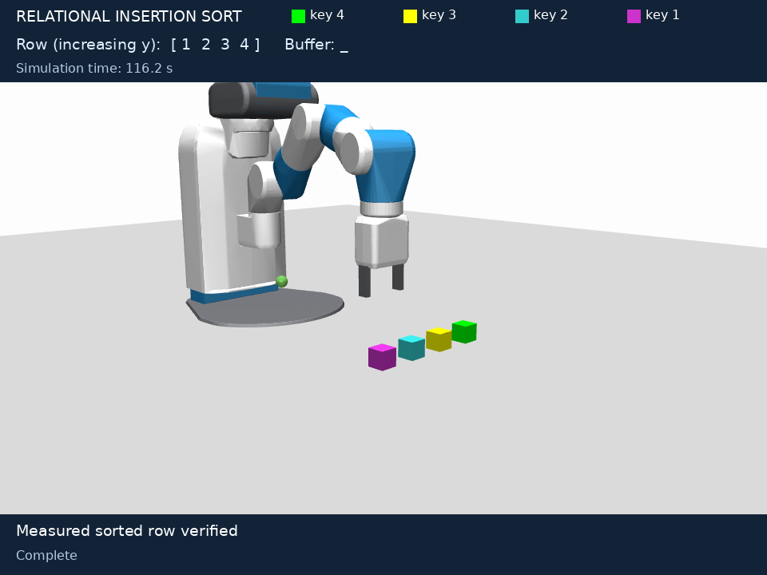

```python
table(["Artifact", "Path"], [
    ["Executed notebook", f"{PREFIX}.ipynb"], ["Video", VIDEO.name],
    ["Measured guard trace", TRACE_FIGURE.name], ["Physical corpus", TRACES.name],
    ["Learned formulas and checks", REPORT.name],
    ["Outer SMT", f"{PREFIX}_outer.smt2"], ["Inner SMT", f"{PREFIX}_inner.smt2"],
])
env.close()
display(Image(filename=str(OUT / f"{PREFIX}_final.png"), width=850))
```